# Exponential distribution in R

### Author: D.Aiazzi

## Overview

We investigate the exponential distribution in R. With the Central Limit Theorem (CLT) we compare the theoretical population distribution simulated by ‘rexp()’ with the distribution of 1000 samples of 40 exponentials.  
In particular we want to:  
1. Show the sample mean and compare it to the theoretical mean of the distribution.  
2. Show how variable the sample is (via variance) and compare it to the theoretical variance of the distribution.  
3. Show that the distribution is approximately normal.

## Simulation

We assume X to be an exponential distribution with lambda $\lambda$ = 0.2. It follows that the theoretiacl distribution X has mean $\mu$ = 1/$\lambda$ and standard deviation sd = 1/$\lambda$

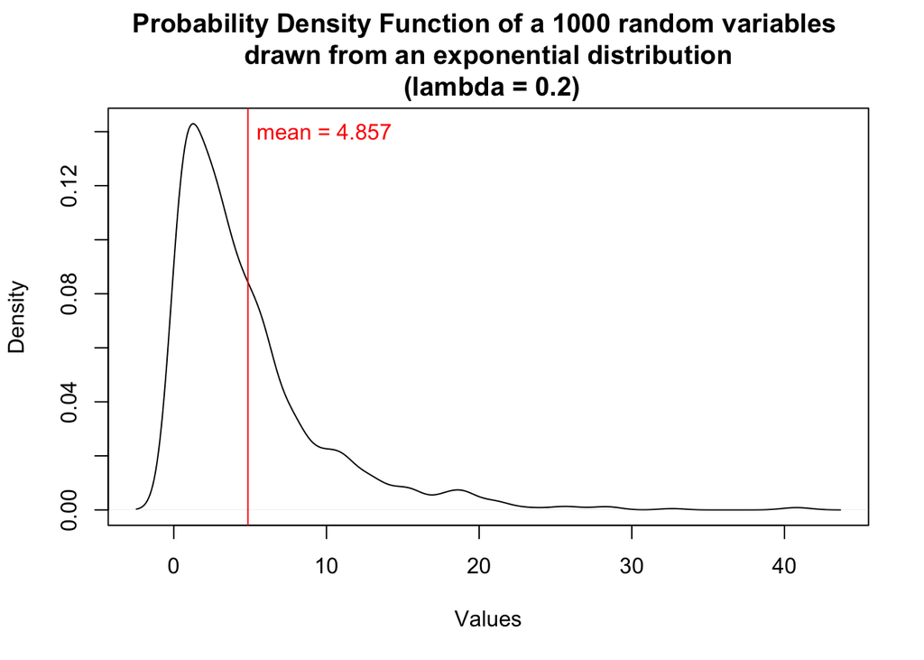

### 1. Theoretical versus sample mean

In the exponential distribution the theoretical mean is $\mu$ = 1/$\lambda$, that is:

```
## [1] 5
```

The mean of the 1000 exponentials is:

```
## [1] "mean of the exponentials = 4.8574"
```

The mean of the averages of samples is closer to the theoretical mean than the mean of the exponentials:

```
## [1] "mean of the averages = 4.9972"
```

Below the distribution of the averages of samples X’ that is centered on the population mean, of whom is an estimate.

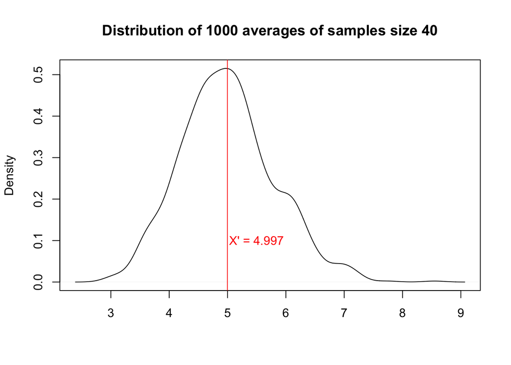

### 2. Theoretical versus sample variance

The theoretical variance of the exponential distribution is Var[X] = 1/$\lambda^{2}$, in this case:

```
## [1] 25
```

The sample variance Var[X’] is:

```
## [1] 0.6440288
```

### 3. Distribution

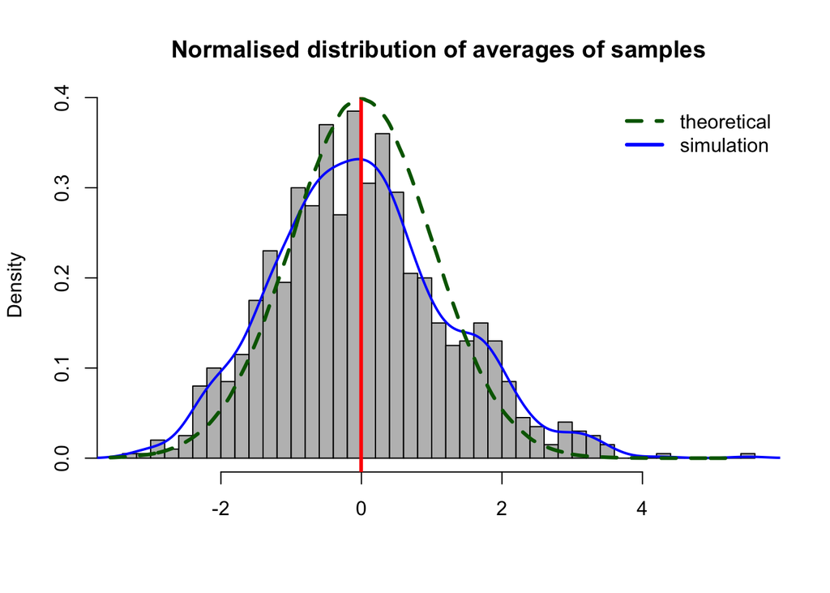

## Appendix

### The code

```r
####SIMULATION####
set.seed(100)
#exponential distribution
lambda <- 0.2
distr_size <- 1000
exponentials <- rexp(distr_size, rate = lambda)
#matrix of 1000 simulations of samples of size 40
n_sim <- 1000
sample_size <- 40
m <- matrix(rexp(n_sim*sample_size, rate = lambda), nrow = n_sim, ncol = sample_size)
#vector of 1000 averages of samples
sample_averages <- apply(m, 1, mean)

plot(density(exponentials),
     lwd = 1,
     main = "Probability Density Function of a 1000 random variables \ndrawn from an exponential distribution\n (lambda = 0.2)",
     xlab = "Values",
     ylab = "Density")
abline(v = mean(exponentials), col = "red")
text(x = mean(exponentials) + 5,
     y = 0.14,
     col = "red",
     labels = paste("mean =", round(mean(exponentials), 3), sep = " "))
#### 1. Theoretical versus sample mean ####
mu <- 1/lambda
mu
#The mean of the 1000 exponentials is:
print(paste("mean of the exponentials =", round(mean(exponentials), 4), sep = " "))
#The mean  of the averages of samples is closer to the theoretical mean
#than the mean of the exponentials:
print(paste("mean of the averages =", round(mean(sample_averages), 4), sep = " "))
#Below the distribution of the averages of samples X'
#that is centered on the population mean, of whom is an estimate.
plot(density(sample_averages),
     main = "Distribution of 1000 averages of samples size 40",
     xlab = "" )
abline(v = mean(sample_averages), col = "red")
text(x = mean(sample_averages) + .5,
     y = .1,
     labels = paste("X' =", round(mean(sample_averages), 3), sep = " "),
     col = "red")

#### 2. Theoretical versus sample variance ####
1/(lambda^2)
var(sample_averages)

#### 3. Distribution ####
#normalisation of the averages of samples
sample_averages_norm <- (sample_averages - mu)/var(sample_averages)
#plot the graph
hist(sample_averages_norm,
     breaks = 50,
     col = "grey",
     prob = TRUE,
     main = "Normalised distribution of averages of samples",
     xlab = "")
lines(density(sample_averages_norm), col = "blue", lwd = 2)
abline(v=mean(sample_averages_norm), col="red", lwd = 3)
lines(density(rnorm(1000000)), lty = 2, lwd = 3, col = "darkgreen")
legend('topright',
       c("theoretical", "simulation"),
       col = c("darkgreen", "blue"),
       lty = c(2,1),
       lwd = 3,
       bty = "n")
```